# Rapport - Données manquantes

#### Nom et Prénom des étudiants du groupe :

[output not shown]

### 1. Introduction

Présentation des données et objectifs de l’étude

https://www.kaggle.com/uciml/pima-indians-diabetes-database

- Context This dataset is originally from the National Institute of Diabetes and Digestive and Kidney Diseases. The objective of the dataset is to diagnostically predict whether or not a patient has diabetes, based on certain diagnostic measurements included in the dataset. Several constraints were placed on the selection of these instances from a larger database. In particular, all patients here are females at least 21 years old of Pima Indian heritage.
- Content The datasets consists of several medical predictor variables and one target variable, Outcome. Predictor variables includes the number of pregnancies the patient has had, their BMI, insulin level, age, and so on.
- Objectif Prédire si l’individu a le diabête ou pas. Construire un modèle dans ce but. Auparavant compléter les données manquante par imputation multiple.

Columns

npreg : PregnanciesNumber of times pregnant glu : GlucosePlasma glucose concentration a 2 hours in an oral glucose tolerance test bp : BloodPressureDiastolic blood pressure (mm Hg) skin : SkinThicknessTriceps skin fold thickness (mm) Insuline : Insulin2-Hour serum insulin (mu U/ml) bmi : BMIBody mass index (weight in kg/(height in m)^2) ped : DiabetesPedigreeFunctionDiabetes pedigree function age : AgeAge (years) type : OutcomeClass variable (0 or 1) 268 of 768 are 1, the others are 0

- Librayries

```r
library(missMDA);
library(mice);
```

#### Chargement des donnés - Résumé

```r
data<-read.table("Pima_DataWithNA.txt",sep=";" ,header=T, na.strings = "NA")
#View(data)
summary(data)
```

```
##        Id            npreg             glu              bp
##  Min.   :  1.0   Min.   : 0.000   Min.   : 44.0   Min.   : 24.00
##  1st Qu.:192.8   1st Qu.: 1.000   1st Qu.: 99.0   1st Qu.: 64.00
##  Median :384.5   Median : 3.000   Median :117.0   Median : 72.00
##  Mean   :384.5   Mean   : 3.845   Mean   :121.7   Mean   : 72.41
##  3rd Qu.:576.2   3rd Qu.: 6.000   3rd Qu.:141.0   3rd Qu.: 80.00
##  Max.   :768.0   Max.   :17.000   Max.   :199.0   Max.   :122.00
##                                   NA's   :5       NA's   :35
##       skin          Insuline           bmi             ped
##  Min.   : 7.00   Min.   : 14.00   Min.   :18.20   Min.   :0.0780
##  1st Qu.:22.00   1st Qu.: 76.25   1st Qu.:27.50   1st Qu.:0.2437
##  Median :29.00   Median :125.00   Median :32.30   Median :0.3725
##  Mean   :29.15   Mean   :155.55   Mean   :32.46   Mean   :0.4719
##  3rd Qu.:36.00   3rd Qu.:190.00   3rd Qu.:36.60   3rd Qu.:0.6262
##  Max.   :99.00   Max.   :846.00   Max.   :67.10   Max.   :2.4200
##  NA's   :227     NA's   :374      NA's   :11
##       age             type
##  Min.   :21.00   Min.   :0.000
##  1st Qu.:24.00   1st Qu.:0.000
##  Median :29.00   Median :0.000
##  Mean   :33.24   Mean   :0.349
##  3rd Qu.:41.00   3rd Qu.:1.000
##  Max.   :81.00   Max.   :1.000
##
```

- Traitement des données

```r
#suppression de la 1er colonne (Id) et de la 6ème (Insuline)=> trop de données manquantes (peourrait être considérés dans un 2nd tps)
tab_Pima1<-data[,-1]
tab_Pima1<-tab_Pima1[,-5]
data_Pima1<-as.data.frame.matrix(tab_Pima1)

data_Pima1$type <- as.logical(data_Pima1$type)


dataPima<-data_Pima1[,1:8]

#View(data_Pima1)
```

### 2. Exploration des données

```
https://www.kaggle.com/laozhang/statistical-learning-with-r
https://www.kaggle.com/naveenkhasa/pima-indian-diabetes-dataset
```

#### Classification des données manqunates: MCAR/MNAR

https://datascienceplus.com/imputing-missing-data-with-r-mice-package/

Using mice for looking at missing data pattern The mice package provides a nice function md.pattern() to get a better understanding of the pattern of missing data

[figure not shown]

[output not shown]

```r
library(mice)
md.pattern(data)
```

A perhaps more helpful visual representation can be obtained using the VIM package as follows

```r
library(VIM)
```

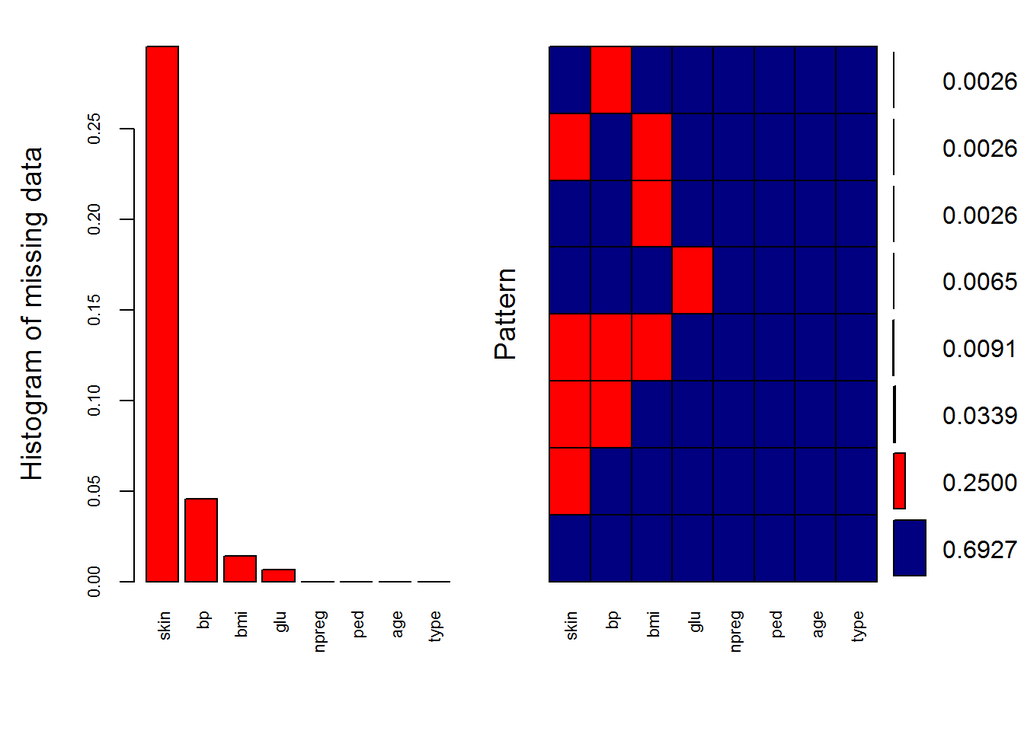

```
##
##  Variables sorted by number of missings:
##  Variable       Count
##      skin 0.295572917
##        bp 0.045572917
##       bmi 0.014322917
##       glu 0.006510417
##     npreg 0.000000000
##       ped 0.000000000
##       age 0.000000000
##      type 0.000000000
```

```r
aggr_plot <- aggr(dataPima, col=c('navyblue','red'), numbers=TRUE, sortVars=TRUE, labels=names(dataPima), cex.axis=.7, gap=3, ylab=c("Histogram of missing data","Pattern"))
```

Another (hopefully) helpful visual approach is a special box plot

[figure not shown]

```r
marginplot(data[c(1,2)])
```

### 3. Imputation

Dans un premier temps on traite les valeurs manquantes. A partir des jeux de données complétés par imputation (test de différents méthodes) simple ou multiple on construit un modèle de type logit pour la variable réponse. Dans notre cas Le patient est diabétique ou pas.

#### 3.2 Imputation multiple avec MIPCA

- Détermination de la dimension de l’espace de projection

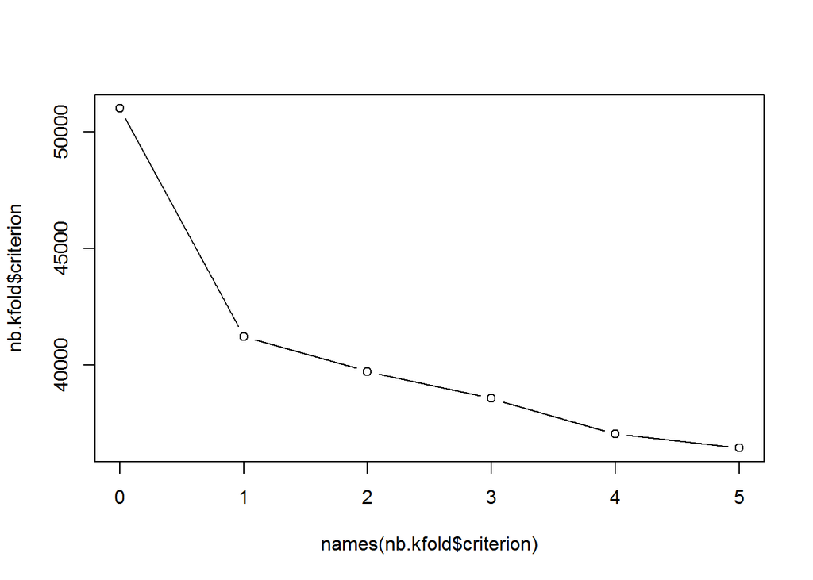

```r
plot(names(nb.kfold$criterion),nb.kfold$criterion,type="b")
```

nb_Pima1 = 1 nb.kfold$ncp = 5

big différence! Les résultats sont meilleur avec 5

```r
#setting des variables
ncp.res<-nb.kfold$ncp
#ncp.res<-nb_Pima1$ncp
dataImp<-data_Pima1[,1:8]
dataPima<-data_Pima1[,1:8]
```

#### 3.2.2 Multiple Imputation with Bayesian method et EM

=> pas vraiment d’améliorations

#### 3.2.4 Multiple Imputation with MIPCA Boost method

Le obtenu par boostrap et method= “EM” semble le meilleur résultat!!!! Yeaaah l’espoir rené!

```r
## Diagnostics
res.overEMBoot_Pima1<-Overimpute(res.EMBootMIPCA_Pima1)
```

[figure not shown]

#### 3.3 Imputation multiple autres méthodes

```r
#res.MIFAMD_Pima1<-MIFAMD(X=dataImp, ncp = ncp.res, # method = c("Regularized", "EM"),
#                              coeff.ridge = 1, threshold = 1e-06,
#       seed = NULL, maxiter = 100, nboot = 20, verbose = T)
```

### 4. Modélisation de la variable réponse

Regression on the multiply imputed data set and pooling with mice

```r
dataPima<-data_Pima1[,1:8] #dataImp
#mi<-res.BayesMIPCA_Pima1
mi.res<-res.EMBootMIPCA_Pima1

#modele1<-glm(type ~ npreg + glu + bp + skin + bmi +  ped + age, family = binomial)
#modele2<-glm(type ~ npreg + glu + ped, family = binomial)

imp_Pima1<-prelim(res.mi=mi.res,X=dataPima)#creating a mids object

#MICE: with.mids Evaluate an expression in multiple imputed datasets
fit_Pima1_m1 <- with(data=imp_Pima1,exp=glm(type ~ npreg + glu + bp + skin + bmi +  ped + age,family=binomial))
fit_Pima1_m2 <- with(data=imp_Pima1,exp=glm(type ~ npreg + glu + bp + bmi +  ped + age ,family=binomial))
fit_Pima1_m3 <- with(data=imp_Pima1,exp=glm(type ~ npreg + glu + skin + bmi +  ped + age,family=binomial))
fit_Pima1_m4 <- with(data=imp_Pima1,exp=glm(type ~ npreg + glu + bmi +  ped + age,family=binomial))
fit_Pima1_m5 <- with(data=imp_Pima1,exp=glm(type ~ npreg + glu + bmi +  ped ,family=binomial))
fit_Pima1_m6 <- with(data=imp_Pima1,exp=glm(type ~ npreg + glu + bmi +  ped ,family=binomial))
fit_Pima1_m7 <- with(data=imp_Pima1,exp=glm(type ~ npreg + glu + ped ,family=binomial))
fit_Pima1_m8 <- with(data=imp_Pima1,exp=glm(type ~ glu + ped ,family=binomial))

#anova.imp <- with(data=imp_Pima1,exp=anova(lm(type ~ npreg + glu + bp + skin + bmi +  ped + age)))



#res.pool_Pima1_anova<-pool(anova.imp);
```

#### Choix du modèle

```r
anova(fit_Pima1_m4,fit_Pima1_m5)
```

```
##    test statistic df1      df2 df.com   p.value        riv
##  1 ~~ 2  1.548071   1 759.3299    762 0.2138044 0.01017338
```

```r
anova(fit_Pima1_m4,fit_Pima1_m3)
```

```
##    test statistic df1      df2 df.com   p.value       riv
##  2 ~~ 1  2.390686   1 303.4207    761 0.1231024 0.7572323
```

```r
anova(fit_Pima1_m4,fit_Pima1_m3)
```

```
##    test statistic df1      df2 df.com   p.value       riv
##  2 ~~ 1  2.390686   1 303.4207    761 0.1231024 0.7572323
```

```r
anova(fit_Pima1_m1,fit_Pima1_m2)
```

```
##    test statistic df1      df2 df.com   p.value       riv
##  1 ~~ 2  2.550764   1 339.4843    760 0.1111713 0.6398037
```

```r
anova(fit_Pima1_m1,fit_Pima1_m3)
```

```
##    test statistic df1      df2 df.com    p.value       riv
##  1 ~~ 2  3.893111   1 555.1672    760 0.04898013 0.2676295
```

```r
anova(fit_Pima1_m1,fit_Pima1_m4)
```

```
##    test statistic df1      df2 df.com    p.value       riv
##  1 ~~ 2  3.105744   2 546.5812    760 0.04558258 0.4552722
```

```r
anova(fit_Pima1_m1,fit_Pima1_m5)
```

```
##    test statistic df1      df2 df.com    p.value      riv
##  1 ~~ 2  2.677569   3 660.6849    760 0.04621257 0.310602
```

```r
anova(fit_Pima1_m1,fit_Pima1_m6)
```

```
##    test statistic df1      df2 df.com    p.value      riv
##  1 ~~ 2  2.677569   3 660.6849    760 0.04621257 0.310602
```

```r
anova(fit_Pima1_m1,fit_Pima1_m7)
```

```
##    test statistic df1      df2 df.com      p.value       riv
##  1 ~~ 2  7.723336   4 649.7088    760 4.399075e-06 0.4119287
```

```r
anova(fit_Pima1_m1,fit_Pima1_m8)
```

```
##    test statistic df1     df2 df.com      p.value       riv
##  1 ~~ 2  9.413224   5 690.572    760 1.080259e-08 0.3322838
```

```r
anova(fit_Pima1_m6,fit_Pima1_m8)
```

```
##    test statistic df1      df2 df.com      p.value       riv
##  1 ~~ 2  18.38027   2 542.3705    763 1.889865e-08 0.4679449
```

```r
anova(fit_Pima1_m7,fit_Pima1_m8)
```

```
##    test statistic df1      df2 df.com      p.value          riv
##  1 ~~ 2  24.48476   1 762.0026    764 9.223079e-07 0.0006405421
```

Choix du plus petit modèle?

#### Inspecting the distribution of original and imputed data

https://datascienceplus.com/imputing-missing-data-with-r-mice-package/

```r
tempData<-prelim(res.mi=mi.res,X=dataPima)#creating a mids object
```

```r
#xyplot(tempData,type ~ glu + ped,pch=18,cex=1)
```

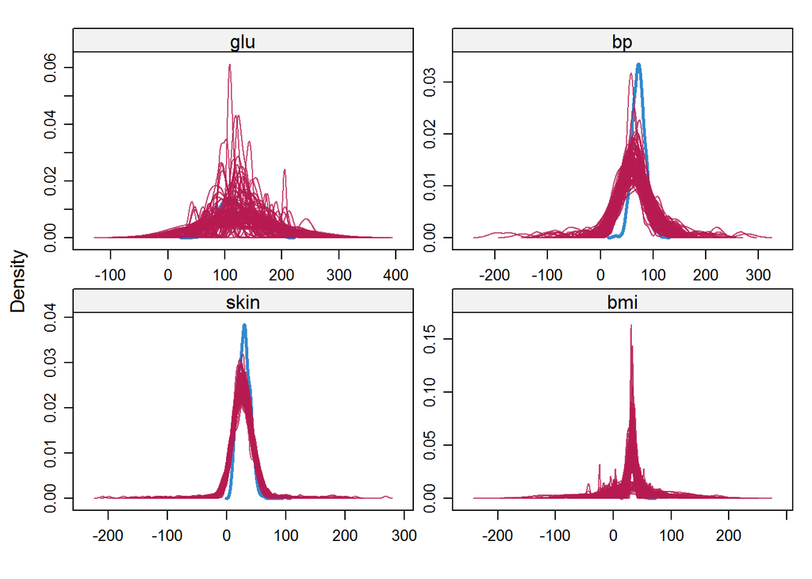

```r
densityplot(tempData)
```

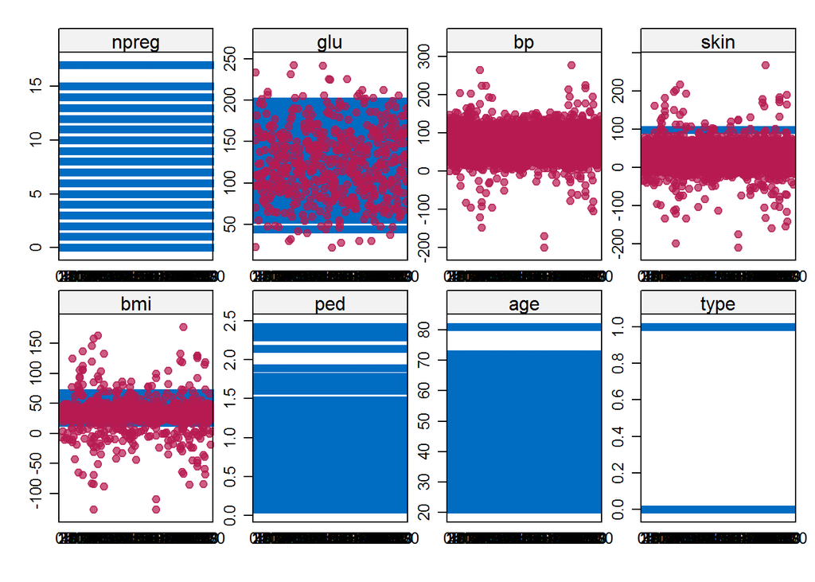

```r
stripplot(tempData, pch = 20, cex = 1.2)
```

#### Pooling

https://datascienceplus.com/imputing-missing-data-with-r-mice-package/

```r
res.pool_Pima1_m1<-pool(fit_Pima1_m1);
res.pool_Pima1_m2<-pool(fit_Pima1_m2);
res.pool_Pima1_m3<-pool(fit_Pima1_m3);
res.pool_Pima1_m4<-pool(fit_Pima1_m4);
res.pool_Pima1_m5<-pool(fit_Pima1_m5);
res.pool_Pima1_m6<-pool(fit_Pima1_m6);
res.pool_Pima1_m7<-pool(fit_Pima1_m7);
res.pool_Pima1_m8<-pool(fit_Pima1_m8);
```

```r
summary(res.pool_Pima1_m1)#pooling
```

|  | estimate | std.error | statistic | df | p.value |
| --- | --- | --- | --- | --- | --- |
| (Intercept) | -8.58442021 | 0.893687855 | -9.605614 | 390.3363 | 0.000000000 |
| npreg | 0.10840597 | 0.033298192 | 3.255611 | 734.0729 | 0.001183416 |
| glu | 0.03763550 | 0.003676668 | 10.236307 | 737.1531 | 0.000000000 |
| bp | -0.01702481 | 0.008628473 | -1.973097 | 471.1289 | 0.049068614 |
| skin | 0.02152195 | 0.013475546 | 1.597111 | 270.1960 | 0.111409732 |
| bmi | 0.06943896 | 0.021364310 | 3.250232 | 466.7834 | 0.001236444 |
| ped | 0.89040322 | 0.300376990 | 2.964286 | 749.9588 | 0.003130002 |
| age | 0.01950167 | 0.009967816 | 1.956464 | 739.2005 | 0.050786668 |

```r
summary(res.pool_Pima1_m2)#pooling
```

|  | estimate | std.error | statistic | df | p.value |
| --- | --- | --- | --- | --- | --- |
| (Intercept) | -8.67916694 | 0.888205883 | -9.771571 | 394.2780 | 0.000000e+00 |
| npreg | 0.11911279 | 0.032466783 | 3.668759 | 754.9367 | 2.608609e-04 |
| glu | 0.03725188 | 0.003646565 | 10.215607 | 738.3591 | 0.000000e+00 |
| bp | -0.01712891 | 0.008473704 | -2.021420 | 492.4297 | 4.377678e-02 |
| bmi | 0.09380460 | 0.017903742 | 5.239385 | 350.0949 | 2.788957e-07 |
| ped | 0.89173189 | 0.299131246 | 2.981072 | 753.5705 | 2.964896e-03 |
| age | 0.01774908 | 0.009798156 | 1.811472 | 746.8587 | 7.046946e-02 |

```r
summary(res.pool_Pima1_m3)#pooling
```

|  | estimate | std.error | statistic | df | p.value |
| --- | --- | --- | --- | --- | --- |
| (Intercept) | -9.14774021 | 0.831368603 | -11.003230 | 434.1627 | 0.0000000000 |
| npreg | 0.10931803 | 0.032961228 | 3.316564 | 738.5851 | 0.0009558899 |
| glu | 0.03672874 | 0.003601556 | 10.198018 | 745.6386 | 0.0000000000 |
| skin | 0.02147709 | 0.013890379 | 1.546184 | 238.6136 | 0.1233852553 |
| bmi | 0.05886123 | 0.021788699 | 2.701457 | 369.7463 | 0.0072215072 |
| ped | 0.89735360 | 0.297709063 | 3.014196 | 748.3868 | 0.0026636305 |
| age | 0.01328462 | 0.009494533 | 1.399186 | 730.8558 | 0.1621814666 |

```r
summary(res.pool_Pima1_m4)#pooling
```

|  | estimate | std.error | statistic | df | p.value |
| --- | --- | --- | --- | --- | --- |
| (Intercept) | -9.25475750 | 0.834793465 | -11.086284 | 416.7332 | 0.000000e+00 |
| npreg | 0.11976740 | 0.032176211 | 3.722234 | 756.6749 | 2.121089e-04 |
| glu | 0.03635954 | 0.003573117 | 10.175862 | 746.4589 | 0.000000e+00 |
| bmi | 0.08329888 | 0.019653056 | 4.238470 | 203.4793 | 3.411737e-05 |
| ped | 0.89924911 | 0.296419466 | 3.033705 | 752.5935 | 2.498795e-03 |
| age | 0.01152458 | 0.009262535 | 1.244215 | 751.7744 | 2.138083e-01 |

```r
summary(res.pool_Pima1_m5)#pooling
```

|  | estimate | std.error | statistic | df | p.value |
| --- | --- | --- | --- | --- | --- |
| (Intercept) | -9.01274555 | 0.79905406 | -11.279269 | 414.2657 | 0.000000e+00 |
| npreg | 0.14093537 | 0.02756201 | 5.113392 | 755.8617 | 4.013648e-07 |
| glu | 0.03726139 | 0.00350802 | 10.621772 | 749.2924 | 0.000000e+00 |
| bmi | 0.08184960 | 0.01956274 | 4.183955 | 204.8054 | 4.249101e-05 |
| ped | 0.90867631 | 0.29586390 | 3.071265 | 753.6488 | 2.208167e-03 |

```r
summary(res.pool_Pima1_m6)#pooling
```

|  | estimate | std.error | statistic | df | p.value |
| --- | --- | --- | --- | --- | --- |
| (Intercept) | -9.01274555 | 0.79905406 | -11.279269 | 414.2657 | 0.000000e+00 |
| npreg | 0.14093537 | 0.02756201 | 5.113392 | 755.8617 | 4.013648e-07 |
| glu | 0.03726139 | 0.00350802 | 10.621772 | 749.2924 | 0.000000e+00 |
| bmi | 0.08184960 | 0.01956274 | 4.183955 | 204.8054 | 4.249101e-05 |
| ped | 0.90867631 | 0.29586390 | 3.071265 | 753.6488 | 2.208167e-03 |

```r
summary(res.pool_Pima1_m7)#pooling
```

|  | estimate | std.error | statistic | df | p.value |
| --- | --- | --- | --- | --- | --- |
| (Intercept) | -6.56629003 | 0.488014978 | -13.455099 | 760.4736 | 0.000000e+00 |
| npreg | 0.13072322 | 0.026418298 | 4.948207 | 761.5176 | 9.224277e-07 |
| glu | 0.03934519 | 0.003442198 | 11.430252 | 759.6473 | 0.000000e+00 |
| ped | 1.00745745 | 0.280834375 | 3.587372 | 761.6486 | 3.553696e-04 |

```r
summary(res.pool_Pima1_m8)#pooling
```

|  | estimate | std.error | statistic | df | p.value |
| --- | --- | --- | --- | --- | --- |
| (Intercept) | -6.11188921 | 0.465095284 | -13.141155 | 760.6869 | 0.0000000000 |
| glu | 0.04026529 | 0.003412583 | 11.799065 | 760.0747 | 0.0000000000 |
| ped | 0.92873394 | 0.277786165 | 3.343341 | 762.6241 | 0.0008681603 |

### 5. Conclusion

Intérêt : Les données Pima sont très utilsées (cf. Kaggle) pour autant il ne semble pas qu’un modèle d’inputation ait été utilisé. Bien souvent les données manquantes sont supprimés ou bien imputatikon simple par moyenne.